# Predicting IMDB rating for Dr. Who (tidytuesday week 48)

Nils Indreiten

Created: 29/11/2021

## Read in the Data

These data are part of [week 48 of the tidytuesday series](https://github.com/rfordatascience/tidytuesday/blob/master/data/2021/2021-11-23/readme.md), it contains information about the Doctro Who TV program. This report was inspired by [Julia Silge](https://juliasilge.com/blog/doctor-who/) .Lets read in the data:

```r
episodes <- readr::read_csv('https://raw.githubusercontent.com/rfordatascience/tidytuesday/master/data/2021/2021-11-23/episodes.csv') # Episode data

imdb <- readr::read_csv('https://raw.githubusercontent.com/rfordatascience/tidytuesday/master/data/2021/2021-11-23/imdb.csv')
```

In order to have the imdb rating for each episdoe in every season, the two datasets need to be joined. This can be achieved using a right join:

```r
# rename columns to join b, prior to joining:
episodes <- episodes %>%
  rename("ep_num"="episode_number",
         "season"="season_number")
# perform a right join to combine the episode and imdb rating data:
ep_imdb <- episodes %>% right_join(imdb, by=c("season", "ep_num"))
# take a look at the data:
glimpse(ep_imdb)
```

```
## Rows: 160
## Columns: 16
## $ era             <chr> "revived", "revived", "revived", "revived", "revived",…
## $ season          <dbl> 1, 1, 1, 1, 1, 1, 1, 1, 1, 1, 1, 1, 1, 2, 2, 2, 2, 2, …
## $ serial_title    <chr> NA, NA, NA, NA, NA, NA, NA, NA, NA, NA, NA, NA, NA, NA…
## $ story_number    <chr> "157", "158", "159", "160a", "160b", "161", "162", "16…
## $ ep_num          <dbl> 1, 2, 3, 4, 5, 6, 7, 8, 9, 10, 11, 12, 13, 1, 2, 3, 4,…
## $ episode_title   <chr> "Rose", "The End of the World", "The Unquiet Dead", "A…
## $ type            <chr> "episode", "episode", "episode", "episode", "episode",…
## $ first_aired     <date> 2005-03-26, 2005-04-02, 2005-04-09, 2005-04-16, 2005-…
## $ production_code <chr> "1.1", "1.2", "1.3", "1.4", "1.5", "1.6", "1.7", "1.8"…
## $ uk_viewers      <dbl> 10.81, 7.97, 8.86, 7.63, 7.98, 8.63, 8.01, 8.06, 7.11,…
## $ rating.x        <dbl> 76, 76, 80, 82, 81, 84, 81, 83, 84, 85, 82, 86, 89, 85…
## $ duration        <dbl> 45, 44, 44, 45, 42, 45, 44, 45, 45, 45, 45, 45, 45, 45…
## $ air_date        <chr> "17 Mar. 2006", "17 Mar. 2006", "24 Mar. 2006", "31 Ma…
## $ rating.y        <dbl> 7.5, 7.5, 7.5, 7.0, 7.0, 8.7, 7.1, 8.4, 9.2, 9.2, 7.1,…
## $ rating_n        <dbl> 8301, 7279, 6804, 6543, 6337, 7211, 6255, 6889, 8383, …
## $ desc            <chr> "When ordinary shop-worker Rose Tyler meets a mysterio…
```

Since the aim of this report is to predict IMDB score of Dr. Who episodes, it might be interesting to visualise how the IMDB ratings fluctuated over time:

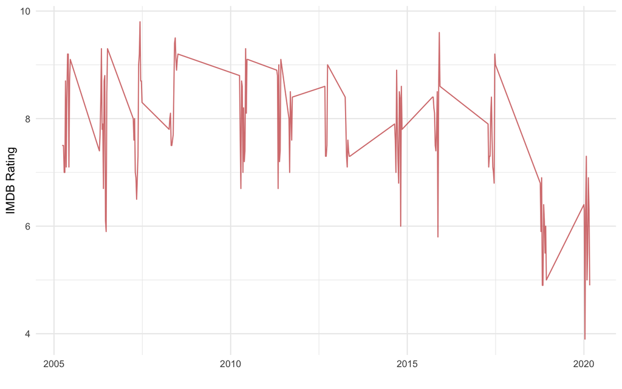

```r
# some minor data cleaning first:
ep_imdb <- ep_imdb %>% rename("rating"="rating.y") %>% select(season, ep_num, first_aired, uk_viewers, rating)

# plot visualisation:
ep_imdb %>%
  ggplot(aes(first_aired, rating))+
  geom_line(alpha=0.8, color="indianred")+
  xlab("")+
  ylab("IMDB Rating")+
  theme_minimal()
```

The fluctuations are quite spiky, indicating steep fluctuations in the ratings across seasons.

## Define a Workflow

First some bootstrap resampling folds for the episodes are created, then a workflow for predicting IMDB rating (out of 10) from a couple of scpeified variables:

```r
set.seed(1080)
folds <- bootstraps(ep_imdb, times = 1000, strata = rating)
folds # take a quick look
```

```
## # Bootstrap sampling using stratification
## # A tibble: 1,000 × 2
##    splits           id
##    <list>           <chr>
##  1 <split [160/56]> Bootstrap0001
##  2 <split [160/53]> Bootstrap0002
##  3 <split [160/57]> Bootstrap0003
##  4 <split [160/56]> Bootstrap0004
##  5 <split [160/60]> Bootstrap0005
##  6 <split [160/53]> Bootstrap0006
##  7 <split [160/51]> Bootstrap0007
##  8 <split [160/63]> Bootstrap0008
##  9 <split [160/56]> Bootstrap0009
## 10 <split [160/58]> Bootstrap0010
## # … with 990 more rows
```

We will be using the first_aired variable as one of the predictors, therefore, some feature engineering is required. In paticular a new date feature indicating the year in which the episdoe aired and another variable indicating holidays celebrated in the UK, will be created. The holiday date variable will give an indication of whether the Dr. Who episode was a New Year’s special.

```r
# Define the recipe:
Dr_Who_rec <- recipe(rating ~ first_aired + uk_viewers, data = ep_imdb) %>%
  step_date(first_aired, features= "year") %>%
   step_holiday(first_aired,
    holidays = c("NewYearsDay"),
    keep_original_cols = FALSE
  )

# Check hwo this will transform the data, by unhashing the line below:
# prep(Dr_Who_rec) %>% bake(new_data= NULL)
```

Combine the recipe with a model, given the limitations in the data size, an OLS linear model will be used:

```r
Dr_Who_wf <- workflow(Dr_Who_rec, linear_reg())
Dr_Who_wf
```

```
## ══ Workflow ════════════════════════════════════════════════════════════════════
## Preprocessor: Recipe
## Model: linear_reg()
##
## ── Preprocessor ────────────────────────────────────────────────────────────────
## 2 Recipe Steps
##
## • step_date()
## • step_holiday()
##
## ── Model ───────────────────────────────────────────────────────────────────────
## Linear Regression Model Specification (regression)
##
## Computational engine: lm
```

## Selecting Specified Quantities from Workflows

We can extract the fitted model by using the ctrl_resamples function, from the control_* family of functions:

```r
ctrl_extract <- control_resamples(extract = extract_fit_engine)
```

This will allow us to keep the linear model from each fitted resample.

```r
doParallel::registerDoParallel()
set.seed(1235)
Dr_Who_res <- fit_resamples(Dr_Who_wf, folds, control =  ctrl_extract)
Dr_Who_res
```

[output not shown]

The tidy() function can be applied to the lm object from each resample, allowing us to see the coefficients.

```r
Dr_Who_res %>%
select(id, .extracts) %>%
  unnest(.extracts) %>%
  mutate(coefs = map(.extracts, tidy)) %>%
  unnest(coefs)
```

```
## # A tibble: 4,000 × 8
##    id            .extracts .config  term   estimate std.error statistic  p.value
##    <chr>         <list>    <chr>    <chr>     <dbl>     <dbl>     <dbl>    <dbl>
##  1 Bootstrap0001 <lm>      Preproc… (Inte… 727.       96.8       7.52   3.53e-12
##  2 Bootstrap0001 <lm>      Preproc… uk_vi…   0.166     0.126     1.32   1.88e- 1
##  3 Bootstrap0001 <lm>      Preproc… first…  -0.320     0.0479   -6.68   3.52e-10
##  4 Bootstrap0001 <lm>      Preproc… first…  -0.0302    1.16     -0.0261 9.79e- 1
##  5 Bootstrap0002 <lm>      Preproc… (Inte… 718.       96.1       7.47   4.73e-12
##  6 Bootstrap0002 <lm>      Preproc… uk_vi…   0.229     0.134     1.70   9.04e- 2
##  7 Bootstrap0002 <lm>      Preproc… first…  -0.316     0.0476   -6.64   4.50e-10
##  8 Bootstrap0002 <lm>      Preproc… first…   1.38      1.37      1.01   3.16e- 1
##  9 Bootstrap0003 <lm>      Preproc… (Inte… 499.       97.3       5.13   8.25e- 7
## 10 Bootstrap0003 <lm>      Preproc… uk_vi…   0.403     0.143     2.81   5.52e- 3
## # … with 3,990 more rows
```

Finally we can visualise the coeeficients according to the predictor variables:

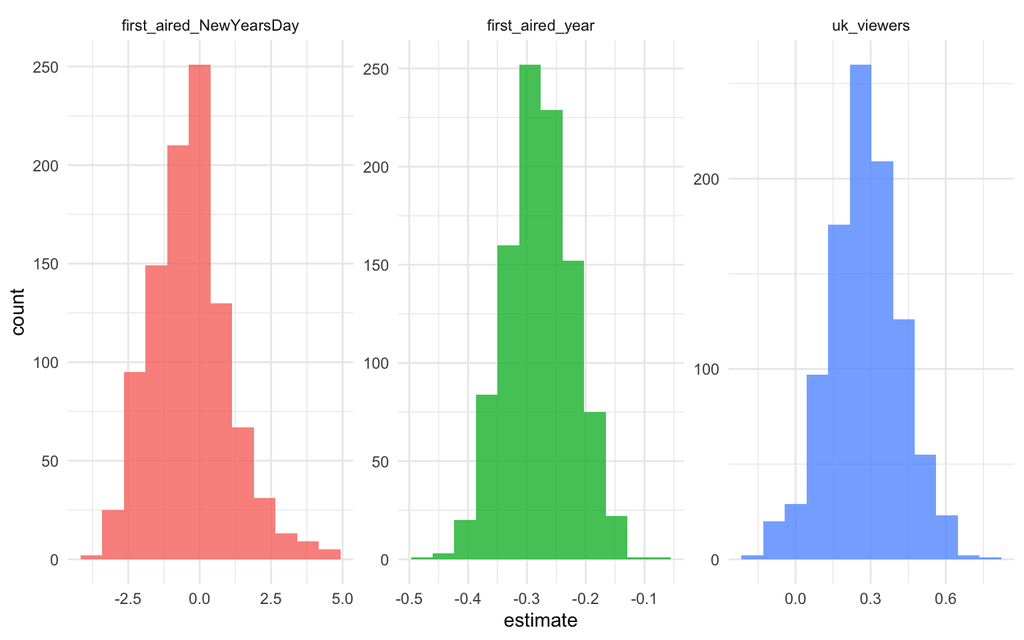

```r
Dr_Who_res %>%
  select(id, .extracts) %>%
  unnest(.extracts) %>%
  mutate(coefs = map(.extracts, tidy)) %>%
  unnest(coefs) %>%
  filter(term != "(Intercept)") %>%
  ggplot(aes(estimate, fill = term)) +
  geom_histogram(alpha = 0.8, bins = 12, show.legend = FALSE) +
  facet_wrap(vars(term), scales = "free")+
  theme_minimal()
```